# Custom CNV Calling

Simon Renny-Byfield

February 23, 2015

## Introduction

After trying several programs trying to call CNV, we have been pretty dissatisfied with the output. Generally, the programs do not run samples together in one run, do not produce similar results with varying parameters, or true positive (TP) and false positive (FP) [as a percentage] track each other perfectly (i.e. calls are more or less random; estimates are based on a “Gold Standard” of the Swanson-Wagner CNV CGH Chip).

Jeff and I decided to try writting something on our own. The approach is a simple one and there are several points to make before we begin. We will:

- Focusing on genes, seeing as this is where we can call most of the SNPs anyway.
- Use read-depth (normalized) per million per kb of gene, to inform copy number.
- Also adjust coverage to GC conent of the gene.
- Take advatage of B73 as a reference sample.

## Generating the coverage data

The first task is to generate coverage data for each gene. Jeff and I decided to use strict mapping criteria, I filtered with samtools with `-MINMAPQ 30`, using something that looks like this:  
`samtools view -bhq 30 ../$file > filtered_$file`  
The data used are stored in `/group/jrigrp4/cn.mops/data/filtered_bams` and have been filtered to **minimum map quality of 30**. Subsequent to filterring the data I then used [`bedtools`](http://bedtools.readthedocs.org/en/latest/) to generate coverage data. This is realtively easy with a simple one liner using the `multicov` call. The followign bedtools run was executed from within the dir `/group/jrigrp4/cn.mops/data/filtered_bams`.  
`bedtools multicov -bams *.bam -bed ../../../freec/maize3/GeneZeaRefV3.bed -q 30 -p > coverage.per.gene.txt` In order to find which column is which, I grabbed the output of `ls *.bam`, giving:

```r
20G -rw-rw-r-- 1 sbyfield jrigrp  20G Feb  2 14:39 filtered_JRIAL2A.sorted.bam
 17G -rw-rw-r-- 1 sbyfield jrigrp  17G Feb  2 14:21 filtered_JRIAL2B.sorted.bam
 17G -rw-rw-r-- 1 sbyfield jrigrp  17G Feb  2 14:15 filtered_JRIAL2C.sorted.bam
 21G -rw-rw-r-- 1 sbyfield jrigrp  21G Feb  2 14:42 filtered_JRIAL2D.sorted.bam
 17G -rw-rw-r-- 1 sbyfield jrigrp  17G Feb  2 14:13 filtered_JRIAL2E.sorted.bam
 17G -rw-rw-r-- 1 sbyfield jrigrp  17G Feb  2 14:18 filtered_JRIAL2F.sorted.bam
 17G -rw-rw-r-- 1 sbyfield jrigrp  17G Feb  2 15:16 filtered_JRIAL2G.sorted.bam
 17G -rw-rw-r-- 1 sbyfield jrigrp  17G Feb  2 15:23 filtered_JRIAL2H.sorted.bam
 21G -rw-rw-r-- 1 sbyfield jrigrp  21G Feb  2 15:41 filtered_JRIAL2I.sorted.bam
 17G -rw-rw-r-- 1 sbyfield jrigrp  17G Feb  2 15:10 filtered_JRIAL2J.sorted.bam
 19G -rw-rw-r-- 1 sbyfield jrigrp  19G Feb  2 16:11 filtered_JRIAL2K.sorted.bam
 19G -rw-rw-r-- 1 sbyfield jrigrp  19G Feb  2 16:12 filtered_JRIAL2L.sorted.bam
 19G -rw-rw-r-- 1 sbyfield jrigrp  19G Feb  2 16:14 filtered_JRIAL2M.sorted.bam
 17G -rw-rw-r-- 1 sbyfield jrigrp  17G Feb  2 16:00 filtered_JRIAL2N.sorted.bam
 16G -rw-rw-r-- 1 sbyfield jrigrp  16G Feb  2 16:07 filtered_JRIAL2O.sorted.bam
 16G -rw-rw-r-- 1 sbyfield jrigrp  16G Feb  2 16:16 filtered_JRIAL2P.sorted.bam
 20G -rw-rw-r-- 1 sbyfield jrigrp  20G Feb  2 16:51 filtered_JRIAL2Q.sorted.bam
 19G -rw-rw-r-- 1 sbyfield jrigrp  19G Feb  2 16:45 filtered_JRIAL2R.sorted.bam
 18G -rw-rw-r-- 1 sbyfield jrigrp  18G Feb  2 16:40 filtered_JRIAL2S.sorted.bam
 17G -rw-rw-r-- 1 sbyfield jrigrp  17G Feb  2 16:43 filtered_JRIAL2T.sorted.bam
8.2G -rw-rw-r-- 1 sbyfield jrigrp 8.2G Feb  2 16:00 filtered_TIL01_sorted.bam
```

The output of the `bedtools` call was the normalized according to this [script](https://github.com/XLEvolutionist/custom_cnv/blob/master/gene_depth.R). Briefly this involves normalizing by library size and gene size giving mapped reads per million per kb.

## Assesing the data

We will now load in the data from GitHub (should work for anyone) and produce a few diagnostic plots:

```r
# load in some libraries
library(RCurl)
library(data.table)
library(ggplot2)
library(reshape2)
library(scales)
library(EDASeq)
# import the data from GitHub
url<-"https://raw.githubusercontent.com/XLEvolutionist/custom_cnv/master/normDepth.txt"
data <- getURL(url,
               ssl.verifypeer=0L, followlocation=1L)
writeLines(data,'temp.txt')
norm.df<-read.table("temp.txt",header=TRUE)
norm.df<-data.table(norm.df)
```

The next part of the analysis is to look at the distribution of read coverage for all samples:

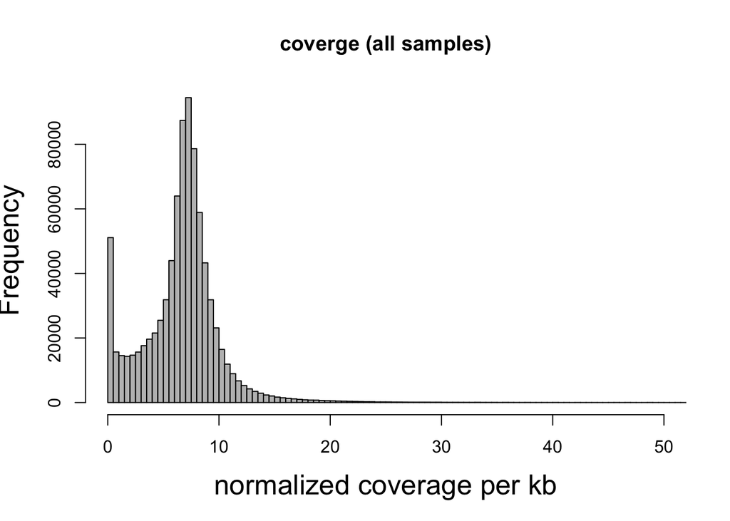

```r
hist(x=melt(subset(norm.df,select=-c(1:4,27,28)))$value, main="coverge (all samples)",
      xlim=c(0,50), xlab="normalized coverage per kb",col="grey",cex.lab=1.6, breaks=5000)
```

At this stage it important to see what the distribution of this coverage is in the reference B73. Any genes that have 0 (or nearly zero) coverage in B73 should be removed. The zero is likely due to bad mapping rather than real missing data, and so we cannot trust RD estimates of these genes in the teosinte lines.

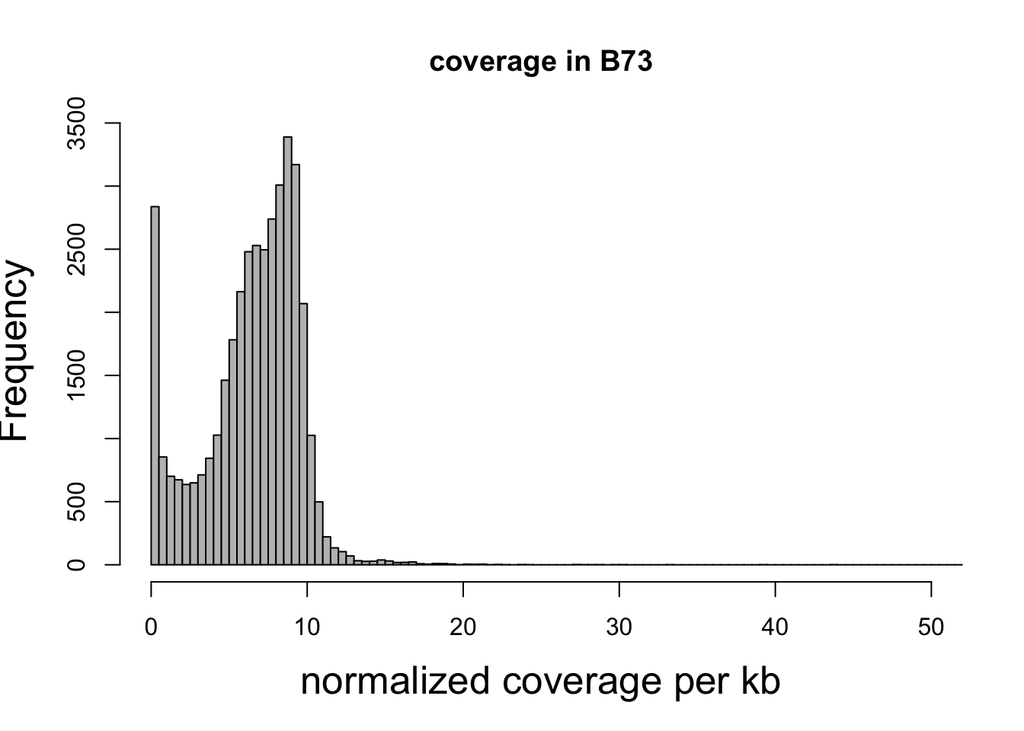

```r
hist(x=subset(norm.df,select="B73.bam")$B73.bam, main="coverage in B73",
      xlim=c(0,50), xlab="normalized coverage per kb",col="grey",cex.lab=1.6, breaks=100)
```

Now, lets have another look at the distribution in B73:

[figure not shown]

## GC content and adjustment with loess smoothing

So far the data look pretty good but how does GC content impact the RD estimates? It can be easily seen that GC content (already a known bias in Illumina data) can impact coverage. Here I plot GC content as a predictor of read depth over genes, using TIL01 as the sample:

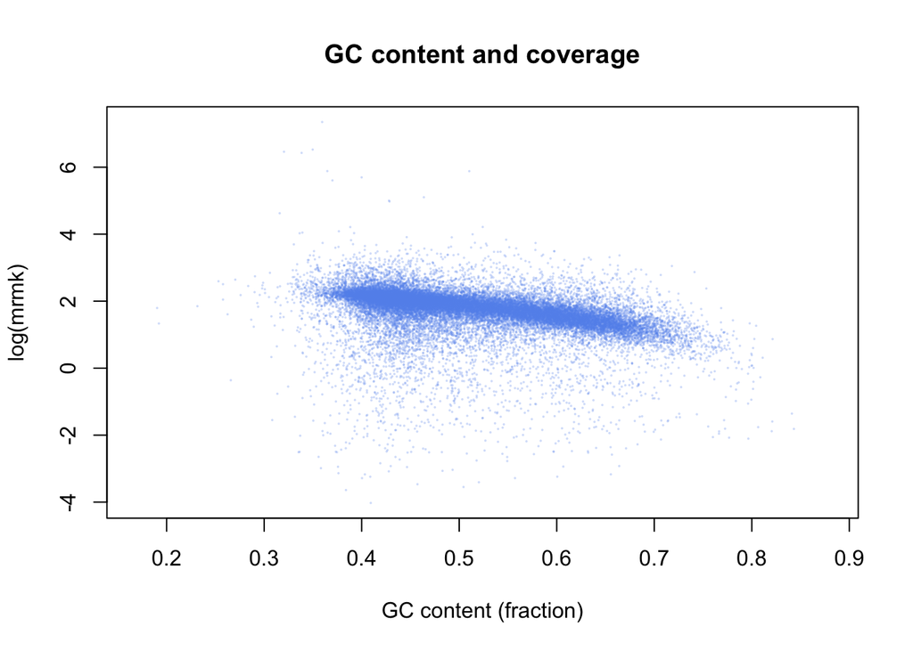

```r
plot(norm.df$pct_gc,log(norm.df$TIL01), main="GC content and coverage", xlab="GC content (fraction)", ylab="log(mrmk)",col = alpha("cornflowerblue", 0.3), cex = 0.1)
```

We have the option of correcting for this using loess smoothing. First we need to melt the data:

```r
meltedNorm<-melt(subset(norm.df,select=-c(1:4,27,28)))
meltedNorm<-cbind(meltedNorm,"gc"=rep(norm.df$pct_gc,22))
print(head(meltedNorm))
```

```
##    variable    value       gc
## 1:  B73.bam 8.623716 0.420786
## 2:  B73.bam 8.875195 0.417958
## 3:  B73.bam 9.909912 0.461402
## 4:  B73.bam 9.850255 0.399930
## 5:  B73.bam 9.392343 0.405322
## 6:  B73.bam 5.295677 0.724409
```

```r
countData<-subset(norm.df,select=-c(1:4,27,28))
countData<-as.matrix(countData)
countData<-newSeqExpressionSet(countData)
head(countData)
```

```
## SeqExpressionSet (storageMode: lockedEnvironment)
## assayData: 1 features, 22 samples
##   element names: counts, normalizedCounts, offset
## protocolData: none
## phenoData: none
## featureData: none
## experimentData: use 'experimentData(object)'
## Annotation:
```

```r
# withinLaneNormalization(x, y)
```